# Consumer Spending Trends & Economic Insights

A reproducible Python analysis — synthetic practice dataset

Author

Prachi Pranesh

Published

October 9, 2026

## Important data note

**This report uses synthetic illustrative data, not official Indian economic statistics.** The values are intended to demonstrate a reproducible analytics workflow. Do not use them to make claims about actual inflation or consumer spending in India.

## Executive summary

This report demonstrates a repeatable workflow for loading, validating, summarising, and visualising monthly inflation-style indicators by consumption category and residence type.

The current dataset covers January–April 2025 and includes urban and rural rows across four consumption categories. The analysis below describes only the synthetic sample.

## 1. Research questions

- How do the sample inflation values vary by consumption category?
- How do average values compare between urban and rural records?
- How do the monthly averages change over the period?
- How can the analysis be organised into reusable Python functions?

## 2. Load the data

```python
import pandas as pd
import matplotlib.pyplot as plt

df = pd.read_csv("consumer_spending_raw_dataset.csv")
df.head()
```

|  | month | country | region | residence_type | consumption_category | yoy_inflation_pct | illustrative_price_index | data_status |
| --- | --- | --- | --- | --- | --- | --- | --- | --- |
| 0 | 2025-01 | India | All India | Urban | Food and beverages | 4.2 | 100.0 | Synthetic example |
| 1 | 2025-01 | India | All India | Urban | Housing | 3.1 | 100.0 | Synthetic example |
| 2 | 2025-01 | India | All India | Urban | Fuel and light | 2.8 | 100.0 | Synthetic example |
| 3 | 2025-01 | India | All India | Urban | Transport | 3.4 | 100.0 | Synthetic example |
| 4 | 2025-01 | India | All India | Rural | Food and beverages | 5.1 | 100.0 | Synthetic example |

## 3. Data quality checks

```python
print("Shape:", df.shape)
print("\nData types and non-null counts:")
df.info()

print("\nMissing values by column:")
display(df.isna().sum().to_frame("missing_values"))

print("\nDuplicate rows:", df.duplicated().sum())
```

```
Shape: (32, 8)

Data types and non-null counts:
<class 'pandas.DataFrame'>
RangeIndex: 32 entries, 0 to 31
Data columns (total 8 columns):
 #   Column                    Non-Null Count  Dtype
---  ------                    --------------  -----
 0   month                     32 non-null     str
 1   country                   32 non-null     str
 2   region                    32 non-null     str
 3   residence_type            32 non-null     str
 4   consumption_category      32 non-null     str
 5   yoy_inflation_pct         32 non-null     float64
 6   illustrative_price_index  32 non-null     float64
 7   data_status               32 non-null     str
dtypes: float64(2), str(6)
memory usage: 2.1 KB

Missing values by column:
```

|  | missing_values |
| --- | --- |
| month | 0 |
| country | 0 |
| region | 0 |
| residence_type | 0 |
| consumption_category | 0 |
| yoy_inflation_pct | 0 |
| illustrative_price_index | 0 |
| data_status | 0 |

```
Duplicate rows: 0
```

Convert the month field to a date and inspect the coverage.

```python
df_clean = df.copy()
df_clean["month"] = pd.to_datetime(df_clean["month"], format="%Y-%m")

print("Date range:", df_clean["month"].min().date(), "to", df_clean["month"].max().date())
print("\nRows per month:")
display(df_clean.groupby("month").size().to_frame("row_count"))

print("\nResidence types:", sorted(df_clean["residence_type"].unique()))
print("Categories:", sorted(df_clean["consumption_category"].unique()))
```

```
Date range: 2025-01-01 to 2025-04-01

Rows per month:
```

| month | row_count |
| --- | --- |
| 2025-01-01 | 8 |
| 2025-02-01 | 8 |
| 2025-03-01 | 8 |
| 2025-04-01 | 8 |

```
Residence types: ['Rural', 'Urban']
Categories: ['Food and beverages', 'Fuel and light', 'Housing', 'Transport']
```

## 4. Average value by consumption category

```python
category_inflation = (
    df_clean.groupby("consumption_category")["yoy_inflation_pct"]
    .mean()
    .sort_values(ascending=False)
)

display(category_inflation.to_frame("average_illustrative_inflation_pct"))
```

| consumption_category | average_illustrative_inflation_pct |
| --- | --- |
| Food and beverages | 4.5750 |
| Transport | 3.2625 |
| Housing | 3.0125 |
| Fuel and light | 2.9500 |

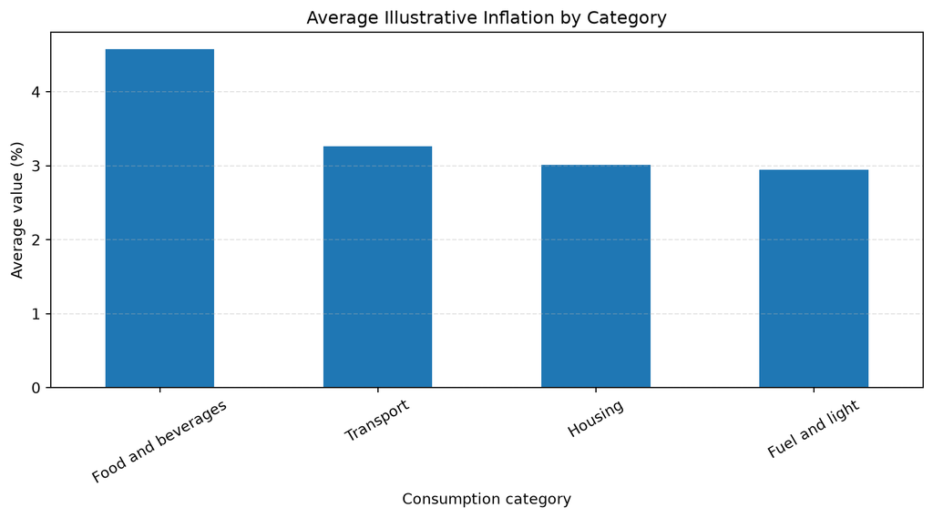

```python
ax = category_inflation.plot(kind="bar", figsize=(9, 5))
ax.set_title("Average Illustrative Inflation by Category")
ax.set_xlabel("Consumption category")
ax.set_ylabel("Average value (%)")
ax.tick_params(axis="x", rotation=30)
ax.grid(axis="y", linestyle="--", alpha=0.35)
plt.tight_layout()
plt.show()
```

**Interpretation:** Use the table and chart to compare category averages in this sample. Because the data is synthetic, these values do not represent official category inflation.

## 5. Urban and rural comparison over time

```python
monthly_trend = (
    df_clean.groupby(["month", "residence_type"])["yoy_inflation_pct"]
    .mean()
    .unstack()
    .sort_index()
)

display(monthly_trend.round(3))
```

| residence_type month | Rural | Urban |
| --- | --- | --- |
| 2025-01-01 | 3.500 | 3.375 |
| 2025-02-01 | 3.675 | 3.550 |
| 2025-03-01 | 3.500 | 3.375 |
| 2025-04-01 | 3.375 | 3.250 |

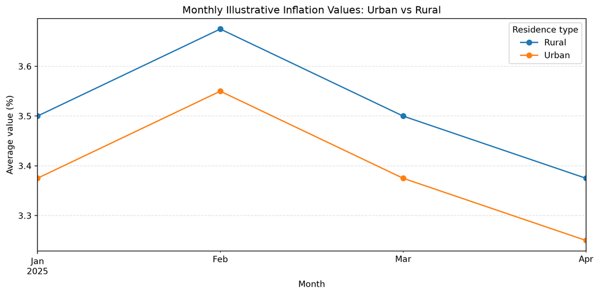

```python
ax = monthly_trend.plot(kind="line", marker="o", figsize=(10, 5))
ax.set_title("Monthly Illustrative Inflation Values: Urban vs Rural")
ax.set_xlabel("Month")
ax.set_ylabel("Average value (%)")
ax.grid(True, linestyle="--", alpha=0.35)
ax.legend(title="Residence type")
plt.tight_layout()
plt.show()
```

## 6. Month-to-month change

This calculation shows the change in the sample year-over-year inflation rate from one month to the next, in **percentage points**. It is not the month-to-month change in consumer prices.

```python
monthly_change = monthly_trend.diff()
display(monthly_change.round(3))
```

| residence_type month | Rural | Urban |
| --- | --- | --- |
| 2025-01-01 | NaN | NaN |
| 2025-02-01 | 0.175 | 0.175 |
| 2025-03-01 | -0.175 | -0.175 |
| 2025-04-01 | -0.125 | -0.125 |

## 7. Reusable analysis functions

The following function validates required columns, aggregates the data and returns a summary table.

```python
def summarize_inflation(data):
    required = {"residence_type", "yoy_inflation_pct"}
    missing = required - set(data.columns)
    if missing:
        raise ValueError(f"Missing required columns: {sorted(missing)}")

    summary = (
        data.groupby("residence_type")["yoy_inflation_pct"]
        .agg(["mean", "min", "max"])
        .rename(columns={
            "mean": "average_pct",
            "min": "minimum_pct",
            "max": "maximum_pct"
        })
        .round(2)
    )
    return summary

display(summarize_inflation(df_clean))
```

| residence_type | average_pct | minimum_pct | maximum_pct |
| --- | --- | --- | --- |
| Rural | 3.51 | 2.7 | 5.4 |
| Urban | 3.39 | 2.6 | 4.5 |

A second reusable function creates the monthly comparison chart.

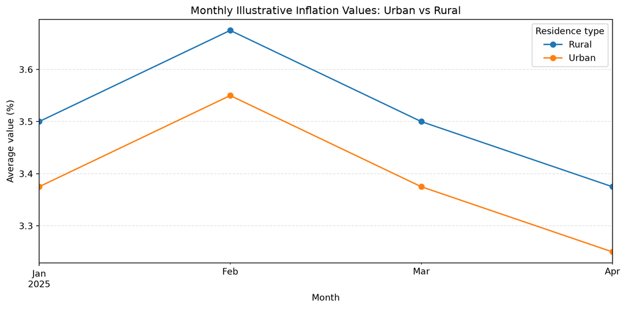

```python
def plot_monthly_inflation(data):
    required = {"month", "residence_type", "yoy_inflation_pct"}
    missing = required - set(data.columns)
    if missing:
        raise ValueError(f"Missing required columns: {sorted(missing)}")

    trend = (
        data.groupby(["month", "residence_type"])["yoy_inflation_pct"]
        .mean()
        .unstack()
        .sort_index()
    )

    ax = trend.plot(kind="line", marker="o", figsize=(10, 5))
    ax.set_title("Monthly Illustrative Inflation Values: Urban vs Rural")
    ax.set_xlabel("Month")
    ax.set_ylabel("Average value (%)")
    ax.grid(True, linestyle="--", alpha=0.35)
    ax.legend(title="Residence type")
    plt.tight_layout()
    plt.show()
    return trend

reusable_trend = plot_monthly_inflation(df_clean)
```

## 8. Findings and limitations

### What this workflow demonstrates

- Loading a CSV into Pandas and validating its quality.
- Converting dates and checking the data’s coverage.
- Grouping and aggregating data by category, month, and residence type.
- Building clear charts with Matplotlib.
- Writing reusable functions with input validation and returned outputs.

### Limitations

- All rows are synthetic examples; results are not real economic findings.
- The dataset covers only four months and four categories.
- No causal relationship can be inferred from these values.
- The field `illustrative_price_index` is an example field and should not be treated as an official price index.

## 9. Next steps

For a portfolio-ready economic analysis:

1. Replace the synthetic CSV with a verified public dataset from a source such as India’s Ministry of Statistics and Programme Implementation or the Reserve Bank of India.
2. Record the exact source URL, download date, definitions, frequency, and units.
3. Re-run the same validation, aggregation, visualisation, and reporting workflow.
4. Compare compatible datasets only after checking their definitions and time periods.
5. Publish the report and source code in a GitHub repository.

## References

- [Quarto documentation](https://quarto.org/docs/)
- [MoSPI eSankhyiki portal](https://esankhyiki.mospi.gov.in/)
- [Reserve Bank of India Database on Indian Economy](https://dbieold.rbi.org.in/DBIE/)